# Kaggle Titanic Survival Prediction

This is from the Kaggle tutorial competition, [Titanic: Machine Learning from Disaster](https://www.kaggle.com/c/titanic). A lot of the codes are adapted from [Dataquest lesson](https://www.dataquest.io/mission/74/getting-started-with-kaggle/) and [Udacity Machine Learning Engineer Nanodegree](https://www.udacity.com/course/machine-learning-engineer-nanodegree--nd009).

In this example, we'll predict survival of passengers by looking at different passenger data, such as age, gender, etc. We'll try three different models---logistic regression, random forest, and extreme gradient boosting.

## Importing necessary packages

We'll need pandas and numpy to work with data frames and do math manipulations. We'll use sklearn for machine learning models. Matplotlib will be also useful in case we want to plot anything!

```python
import pandas as pd
import numpy as np
from sklearn.linear_model import LogisticRegression
from sklearn.ensemble import RandomForestClassifier
from sklearn.model_selection import cross_val_score, KFold
import matplotlib.pyplot as plt
%matplotlib inline
```

## Data import and munging

Now, time to import data and turn all columns into numeric data.

#### Import data

Import train and test data sets from local csv files, then look at first few rows of each.

```python
train = pd.read_csv('train.csv', header=0)
train.head()
```

|  | PassengerId | Survived | Pclass | Name | Sex | Age | SibSp | Parch | Ticket | Fare | Cabin | Embarked |
| --- | --- | --- | --- | --- | --- | --- | --- | --- | --- | --- | --- | --- |
| 0 | 1 | 0 | 3 | Braund, Mr. Owen Harris | male | 22.0 | 1 | 0 | A/5 21171 | 7.2500 | NaN | S |
| 1 | 2 | 1 | 1 | Cumings, Mrs. John Bradley (Florence Briggs Th... | female | 38.0 | 1 | 0 | PC 17599 | 71.2833 | C85 | C |
| 2 | 3 | 1 | 3 | Heikkinen, Miss. Laina | female | 26.0 | 0 | 0 | STON/O2. 3101282 | 7.9250 | NaN | S |
| 3 | 4 | 1 | 1 | Futrelle, Mrs. Jacques Heath (Lily May Peel) | female | 35.0 | 1 | 0 | 113803 | 53.1000 | C123 | S |
| 4 | 5 | 0 | 3 | Allen, Mr. William Henry | male | 35.0 | 0 | 0 | 373450 | 8.0500 | NaN | S |

```python
test = pd.read_csv('test.csv', header=0)
test.head()
```

|  | PassengerId | Pclass | Name | Sex | Age | SibSp | Parch | Ticket | Fare | Cabin | Embarked |
| --- | --- | --- | --- | --- | --- | --- | --- | --- | --- | --- | --- |
| 0 | 892 | 3 | Kelly, Mr. James | male | 34.5 | 0 | 0 | 330911 | 7.8292 | NaN | Q |
| 1 | 893 | 3 | Wilkes, Mrs. James (Ellen Needs) | female | 47.0 | 1 | 0 | 363272 | 7.0000 | NaN | S |
| 2 | 894 | 2 | Myles, Mr. Thomas Francis | male | 62.0 | 0 | 0 | 240276 | 9.6875 | NaN | Q |
| 3 | 895 | 3 | Wirz, Mr. Albert | male | 27.0 | 0 | 0 | 315154 | 8.6625 | NaN | S |
| 4 | 896 | 3 | Hirvonen, Mrs. Alexander (Helga E Lindqvist) | female | 22.0 | 1 | 1 | 3101298 | 12.2875 | NaN | S |

#### Numeric data type

Let's turn sex and embarked into numeric data. Also, we won't bother with Name, Ticket, and Cabin right now, so let's remove those columns.  
'female' = 0, 'male' = 1  
'S' = 0, 'C' = 1, 'Q' = 2

```python
train = train.drop(['Name','Ticket','Cabin'],1)
test = test.drop(['Name','Ticket','Cabin'],1)

train.Sex = train.Sex.map({'female':0, 'male':1}).astype(int)
test.Sex = test.Sex.map({'female':0, 'male':1}).astype(int)

train.Embarked = train.Embarked.fillna('S')
test.Embarked = test.Embarked.fillna('S')
train.Embarked = train.Embarked.map({'S':0, 'C':1, 'Q':2})
test.Embarked = test.Embarked.map({'S':0, 'C':1, 'Q':2})
```

```python
train.head()
```

|  | PassengerId | Survived | Pclass | Sex | Age | SibSp | Parch | Fare | Embarked |
| --- | --- | --- | --- | --- | --- | --- | --- | --- | --- |
| 0 | 1 | 0 | 3 | 1 | 22.0 | 1 | 0 | 7.2500 | 0 |
| 1 | 2 | 1 | 1 | 0 | 38.0 | 1 | 0 | 71.2833 | 1 |
| 2 | 3 | 1 | 3 | 0 | 26.0 | 0 | 0 | 7.9250 | 0 |
| 3 | 4 | 1 | 1 | 0 | 35.0 | 1 | 0 | 53.1000 | 0 |
| 4 | 5 | 0 | 3 | 1 | 35.0 | 0 | 0 | 8.0500 | 0 |

```python
test.head()
```

|  | PassengerId | Pclass | Sex | Age | SibSp | Parch | Fare | Embarked |
| --- | --- | --- | --- | --- | --- | --- | --- | --- |
| 0 | 892 | 3 | 1 | 34.5 | 0 | 0 | 7.8292 | 2 |
| 1 | 893 | 3 | 0 | 47.0 | 1 | 0 | 7.0000 | 0 |
| 2 | 894 | 2 | 1 | 62.0 | 0 | 0 | 9.6875 | 2 |
| 3 | 895 | 3 | 1 | 27.0 | 0 | 0 | 8.6625 | 0 |
| 4 | 896 | 3 | 0 | 22.0 | 1 | 1 | 12.2875 | 0 |

#### Quick break: correlation

Now all our data is numeric. A useful concept to look at is correlation. It informs us of which features are good predictors. We'll look at it both as a table and a plot. We'll have to import another package to make this plot.

```python
import seaborn as sb
```

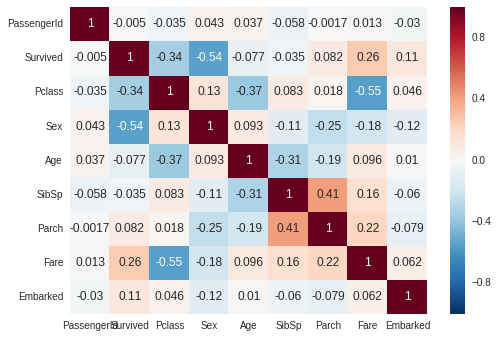

```python
corr = train.corr()
sb.heatmap(corr, annot=True)
plt.show()
```

We can see the sex and passenger class and fare are three biggest predictors. (well, fare and passenger class are most likely related, but whatever...).

#### Dealing with missing values

```python
print(train.isnull().sum())
print(test.isnull().sum())
```

```
PassengerId      0
Survived         0
Pclass           0
Sex              0
Age            177
SibSp            0
Parch            0
Fare             0
Embarked         0
dtype: int64
PassengerId     0
Pclass          0
Sex             0
Age            86
SibSp           0
Parch           0
Fare            1
Embarked        0
dtype: int64
```

Earlier, we filled NA values for Embarked column. I didn't do anything fancy. I already knew S was most common port, and I just filled the missing values with that.  
As shown above, we still have a lot of missing values for Age. We can try to do something more fancy with age, since it appears age is significantly correlated with few other features, namely Pclass and SibSp.  
There's one missing fare value in test data set. Let's just fill this in with median of same Pclass.

```python
for i in range(len(train.Age)):
    if np.isnan(train.Age[i]):
        if train.SibSp[i] == 0:
            train.loc[i,"Age"] = np.nanmedian(train.Age[(train.Pclass==train.Pclass[i]) & (train.SibSp == 0)])
        elif train.SibSp[i] > 0:
            train.loc[i,"Age"] = np.nanmedian(train.Age[(train.Pclass==train.Pclass[i]) & (train.SibSp > 0)])
        else:
            train.loc[i,"Age"] = np.nanmedian(train.Age[train.Pclass==train.Pclass[i]])
for i in range(len(test.Age)):
    if np.isnan(test.Age[i]):
        if test.SibSp[i] == 0:
            test.loc[i,"Age"] = np.nanmedian(train.Age[(train.Pclass == test.Pclass[i]) & (train.SibSp == 0)])
        elif test.SibSp[i] > 0:
            test.loc[i,"Age"] = np.nanmedian(train.Age[(train.Pclass == test.Pclass[i]) & (train.SibSp > 0)])
        else:
            test.loc[i,"Age"] = np.nanmedian(train.Age[train.Pclass == test.Pclass[i]])

test.loc[test.Fare.isnull(),"Fare"] = np.median(train.Fare[train.Pclass == test.Pclass[test.Fare.isnull()].iloc[0]])
```

We can do more, such as extracting out titles from names (Mr., Mrs., Dr., etc.) or calculating family size (SibSp + Parch). Feature engineering is an important portion of machine learning, but I haven't found much helpful feature for this example. If you're interested in how to implement them anyway, see [Dataquest mission](https://www.dataquest.io/mission/75/improving-your-submission).

## Machine Learning

Now that we have the data ready, it's time to train our data. We most likely don't want to use all features as predictors as it would overfit. We can play with different combinations of predictors, but let's just with try the below combination.

```python
features = ["Pclass", "Sex", "Fare", "Age"]
```

Let's create a function that takes an algorithm, trains on a data with features X and labels Y, and gives us the accuracy on 5-fold cross validation set.

```python
def cv_accuracy(X, Y, algorithm):
    kf = KFold(n_splits=5, random_state=1, shuffle=True)
    kf.get_n_splits(train)

    idx_shuf = []
    predictions = []
    for tr, cv in kf.split(X):
        idx_shuf.append(cv)
        x_train = X.iloc[tr,:]
        y_train = Y.iloc[tr]
        algorithm.fit(x_train, y_train)
        cv_pred = algorithm.predict(X.iloc[cv,:])
        predictions.append(cv_pred)
    idx_shuf = np.concatenate(idx_shuf, axis=0)
    predictions = np.concatenate(predictions, axis=0)
    accuracy = np.array(np.round(predictions) == Y.iloc[idx_shuf]).mean()

    return accuracy
```

#### Logistic regression

Let's first look at logistic regression (see [Wikipedia page](https://en.wikipedia.org/wiki/Logistic_regression) for information on it).

```python
alg = LogisticRegression(random_state=2015)
```

```python
accuracy = cv_accuracy(train[features], train['Survived'], alg)
print(accuracy) #0.7845117845
```

```
0.79012345679
```

Accuracy of **79.0%** is okay, but we can try to improve it. Let's try this on test set and see what we get.

```python
predictions = alg.predict(test[features])
submission = pd.DataFrame({
        "PassengerId": test['PassengerId'],
        "Survived": predictions})
submission.to_csv("prediction_logistic.csv", index=False)
```

This gets **75.1%** accuracy on the leaderboard, which's pretty close to the cross validation accuracy.

#### Random Forest

Let's try a slightly more complicated model called [Random Forest Ensemble](https://en.wikipedia.org/wiki/Random_forest) using the same predictors.

```python
alg = RandomForestClassifier(random_state=13, n_estimators=15, min_samples_split=5)
```

```python
accuracy = cv_accuracy(train[features], train['Survived'], alg)
print(accuracy)
```

```
0.812570145903
```

We get **81.3%**, a pretty good improvement over the simple logistic regression. Now, let's apply this to our test set and see what we get.

```python
predictions = alg.predict(test[features])
submission = pd.DataFrame({
        "PassengerId": test['PassengerId'],
        "Survived": predictions})
submission.to_csv("prediction_randomforest.csv", index=False)
```

This actually gives **74.6%** accuracy, lower than our logistic regression! Maybe it's overfitting. Let's see if we can play with parameters to control our overfitting.

#### Parameter Tuning

I wrote some codes adapted from Udacity's Maching Learning Engineer Nanodegree to visualize change in accuracy in terms of change in parameter complexity. I'll look at three parameters in specific: n_estimators, min_samples_split, and max_depth.

```python
import parameter_optimization as po
```

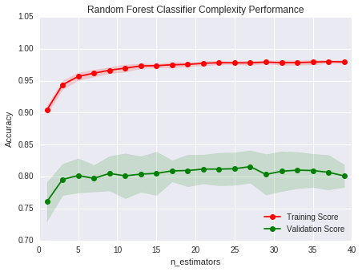

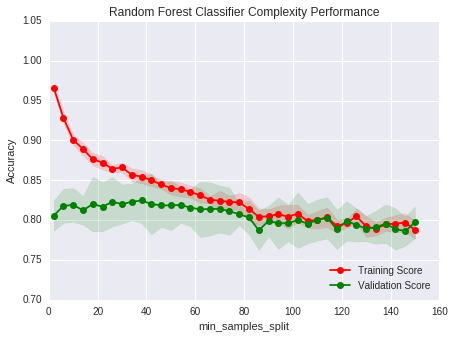

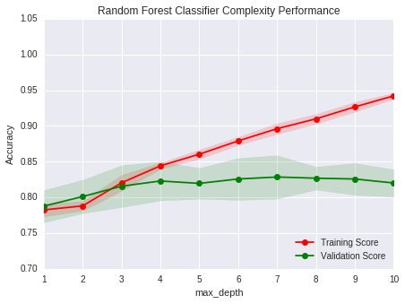

```python
po.NEstimatorComplexity(train[features],train['Survived'],'n_estimators')
po.NEstimatorComplexity(train[features],train['Survived'],'min_samples_split')
po.NEstimatorComplexity(train[features],train['Survived'],'max_depth')
```

We can see that n_estimator and min_sample_split give relatively consistent cross-validation accuracy within some range. max_depth has a minor underfitting at very low values and overfitting at high values.  
It's pretty hard to judge from these plots which parameter values are the best. Let's try something called a grid search, which is a method of looking at the exhaustive combinations of different parameter values to find the optimum parameters for the cross-validation accuracy. (Let's also add min_samples_leaf in there too.)  
For questions on what all these parameters mean, refer to [sklearn doc](http://scikit-learn.org/stable/modules/generated/sklearn.ensemble.RandomForestClassifier.html).

```python
from sklearn.metrics import make_scorer
from sklearn.model_selection import GridSearchCV
acc_score = make_scorer(po.acc_score_func)
```

```python
from sklearn.model_selection import ShuffleSplit
clf = RandomForestClassifier()
params = {'n_estimators': range(5,16),'min_samples_split': range(10,51,1),
          'max_depth': range(1,11), 'min_samples_leaf': range(1,11)}
cv = ShuffleSplit(n_splits = 10, test_size = 0.2, random_state = 2017)
grid = GridSearchCV(clf, params, scoring=acc_score, cv=cv.get_n_splits(train))
grid = grid.fit(train[features],train['Survived'])
```

```python
grid.best_estimator_.get_params()
```

[output not shown]

```python
alg = RandomForestClassifier(random_state=13, max_depth=8, n_estimators=12, min_samples_split=14, min_samples_leaf=3)
```

```python
accuracy = cv_accuracy(train[features], train['Survived'], alg)
print(accuracy)
```

```
0.829405162738
```

**82.9%**, which is a small increase from our non-optimized classifier. That's a good sign!

```python
predictions = alg.predict(test[features])
submission = pd.DataFrame({
        "PassengerId": test['PassengerId'],
        "Survived": predictions})
submission.to_csv("prediction_randomforest_optimized.csv", index=False)
```

This submission gave a accuracy of **77.0**, which is a 2.4% increase from our last one, just by tuning the parameters. Good job!

#### Gradient Boosting

Now let's try a technique called [gradient boosting](https://en.wikipedia.org/wiki/Gradient_boosting) using the library [XGBoost](http://xgboost.readthedocs.io/). XGBoost doc has a good [introduction to gradient boosting](http://xgboost.readthedocs.io/en/latest/model.html) as well.

```python
import xgboost as xgb
```

```python
param = {'max_depth':4, 'gamma':0.5, 'min_child_weight':1,
             'eta':1, 'silent':0, 'objective':'binary:logistic',
             'silent':1, 'seed':29}
```

```python
from sklearn.model_selection import ShuffleSplit
```

Let's re-write our accuracy function for XGBoost. This should look basically the same as our other one.

```python
def xgb_cv_accuracy(X, Y, param):
    num_round = 3
    kf = KFold(n_splits=5, random_state=1, shuffle=True)
    kf.get_n_splits(train)

    idx_shuf = []
    predictions = []
    for tr, cv in kf.split(X):
        idx_shuf.append(cv)

        dtrain = xgb.DMatrix(X.iloc[tr],label=Y.iloc[tr])
        dtest = xgb.DMatrix(X.iloc[cv],label=Y.iloc[cv])

        watchlist  = [(dtest,'validation'),(dtrain,'train')]
        bst = xgb.train(param, dtrain, num_round, watchlist)

        cv_pred = bst.predict(dtest)
        predictions.append(cv_pred)
    idx_shuf = np.concatenate(idx_shuf, axis=0)
    predictions = np.concatenate(predictions, axis=0)
    accuracy = np.array(np.round(predictions) == Y.iloc[idx_shuf]).mean()

    return accuracy
```

```python
accuracy = xgb_cv_accuracy(train[features], train['Survived'],param)
print(accuracy)
```

```
0.805836139169
```

Without tuning any parameter, we got **80.6%** cross-validation accuracy. It seems lower than the random forest ensemble, but let's look at the test accuracy.

```python
dtrain = xgb.DMatrix(train[features],label=train['Survived'])
bst = xgb.train(param, dtrain)
predictions = np.round(bst.predict(xgb.DMatrix(test[features]))).astype(int)
submission = pd.DataFrame({
        "PassengerId": test['PassengerId'],
        "Survived": predictions})
submission.to_csv("prediction_xgboost.csv", index=False)
```

We get **76.6%** test accuracy, close to our last result. Not bad!

Next step should be clear, let's do grid search on xgboost! Unfortunately, xgboost library doesn't come with a grid search technique. However, someone from Kaggle graciously provided an easy way to make xgboost compatible with sklearn classifiers.  
Let's do grid search with bunch of parameters... why not if you have the time, right?

```python
import XGBoost_Classfier as xgb_clf
```

```python
clf = xgb_clf.XGBoostClassifier(num_class=2, silent=1, seed=29)
params = {'num_boost_round': [50,100,150,200],'max_depth': range(4,11), 'eta': np.logspace(-2,-0.4,num=9,base=10.),
          'gamma': np.logspace(-1,1,num=11,base=10.), 'min_child_weight': range(1,6)}
cv = ShuffleSplit(n_splits = 10, test_size = 0.2, random_state = 2017)
clf = GridSearchCV(clf, params, cv=cv.get_n_splits(train))
clf.fit(train[features],train['Survived'])
```

```
GridSearchCV(cv=10, error_score='raise',
       estimator=<XGBoost_Classfier.XGBoostClassifier object at 0x7f7665116208>,
       fit_params={}, iid=True, n_jobs=1,
       param_grid={'gamma': array([  0.1    ,   0.15849,   0.25119,   0.39811,   0.63096,   1.     ,
         1.58489,   2.51189,   3.98107,   6.30957,  10.     ]), 'num_boost_round': [50, 100, 150, 200], 'eta': array([ 0.01   ,  0.01585,  0.02512,  0.03981,  0.0631 ,  0.1    ,
        0.15849,  0.25119,  0.39811]), 'max_depth': range(4, 11), 'min_child_weight': range(1, 6)},
       pre_dispatch='2*n_jobs', refit=True, return_train_score=True,
       scoring=None, verbose=0)
```

```python
best_parameters, score, _ = max(clf.grid_scores_, key=lambda x: x[1])
print(best_parameters)
```

```
{'gamma': 0.39810717055349731, 'max_depth': 4, 'eta': 0.15848931924611143, 'num_boost_round': 50, 'min_child_weight': 2}
```

Again, we use the parameters to see what we get on the test set!

```python
dtrain = xgb.DMatrix(train[features],label=train['Survived'])
bst = xgb.train(best_parameters, dtrain)
predictions = np.round(bst.predict(xgb.DMatrix(test[features]))).astype(int)
submission = pd.DataFrame({
        "PassengerId": test['PassengerId'],
        "Survived": predictions})
submission.to_csv("prediction_xgboost_opt.csv", index=False)
```

This gives **78.5%** test accuracy, nice!

I see that on the Kaggle Public Leaderboard, the benchmark for Gender, Price and Class Based Model is pretty high (78.0%)! Are we overfitting by using the age feature? Well... let's try it without it!

```python
features = ["Pclass", "Sex", "Fare"]
params = {'num_boost_round': [50,100,150,200],'max_depth': range(4,11), 'eta': np.logspace(-2,-0.4,num=9,base=10.),
          'gamma': np.logspace(-1,1,num=11,base=10.), 'min_child_weight': range(1,6)}
clf = xgb_clf.XGBoostClassifier(num_class=2, silent=1, seed=29)
cv = ShuffleSplit(n_splits = 10, test_size = 0.2, random_state = 2017)
clf = GridSearchCV(clf, params, cv=cv.get_n_splits(train))
clf.fit(train[features],train['Survived'])
```

```
GridSearchCV(cv=10, error_score='raise',
       estimator=<XGBoost_Classfier.XGBoostClassifier object at 0x7f76669e1cf8>,
       fit_params={}, iid=True, n_jobs=1,
       param_grid={'gamma': array([  0.1    ,   0.15849,   0.25119,   0.39811,   0.63096,   1.     ,
         1.58489,   2.51189,   3.98107,   6.30957,  10.     ]), 'num_boost_round': [50, 100, 150, 200], 'eta': array([ 0.01   ,  0.01585,  0.02512,  0.03981,  0.0631 ,  0.1    ,
        0.15849,  0.25119,  0.39811]), 'max_depth': range(4, 11), 'min_child_weight': range(1, 6)},
       pre_dispatch='2*n_jobs', refit=True, return_train_score=True,
       scoring=None, verbose=0)
```

```python
best_parameters, score, _ = max(clf.grid_scores_, key=lambda x: x[1])
print(best_parameters)
```

```
{'gamma': 0.25118864315095801, 'max_depth': 5, 'eta': 0.3981071705534972, 'num_boost_round': 200, 'min_child_weight': 1}
```

```python
dtrain = xgb.DMatrix(train[features],label=train['Survived'])
bst = xgb.train(best_parameters, dtrain)
predictions = np.round(bst.predict(xgb.DMatrix(test[features]))).astype(int)
submission = pd.DataFrame({
        "PassengerId": test['PassengerId'],
        "Survived": predictions})
submission.to_csv("prediction_xgboost_opt_noage.csv", index=False)
```

Yay, this gave a slightly lower score of **77.5%** test accuracy, even slight lower than the Gender, Price and Class Based Model benchmark.

#### Last remarks

There are at least one thing wrong here, which I may come back to and fix when I have the time.  
Some of the "optimized" parameters are at an extreme in the range, which may indicate that I didn't look at big enough range.